# Kronecker PCA

Can Hakan Dagidir

2022-05-19

## Data:

- 6 months training 2019 Jan to Jun
- 6 months test 2020 Jan to Jun
- 5 of the datasets have 3x3 locations, the other one (aliaga) has 2x2 locations

## Kronecker PCA in Depth Analysis

### Figure 1

Here we see the change in train and test errors as we change the number of principal components in Kronecker PCA.

The numbers on the plot represent the number of PCs at the lowest test error.

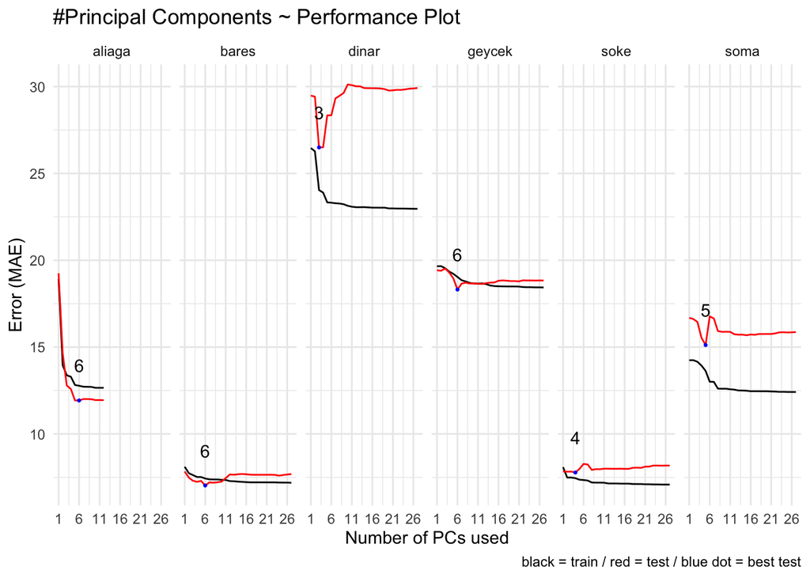

### Figure 2

Here we see the change in explained variance with number of principal components.

Blue and Purple lines represent 99%th and 99.9%th explained varience.

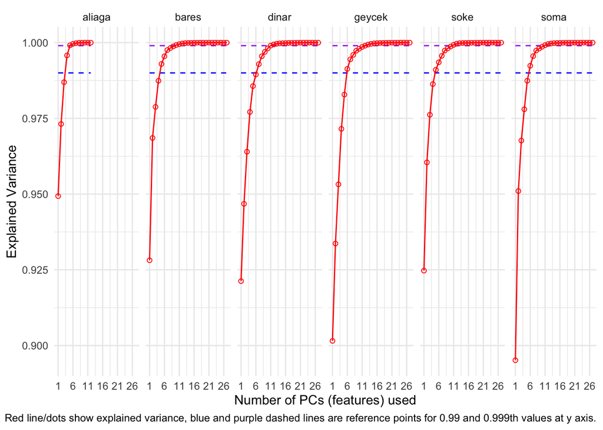

### Close Look

#### Aliaga

Aliaga Plot

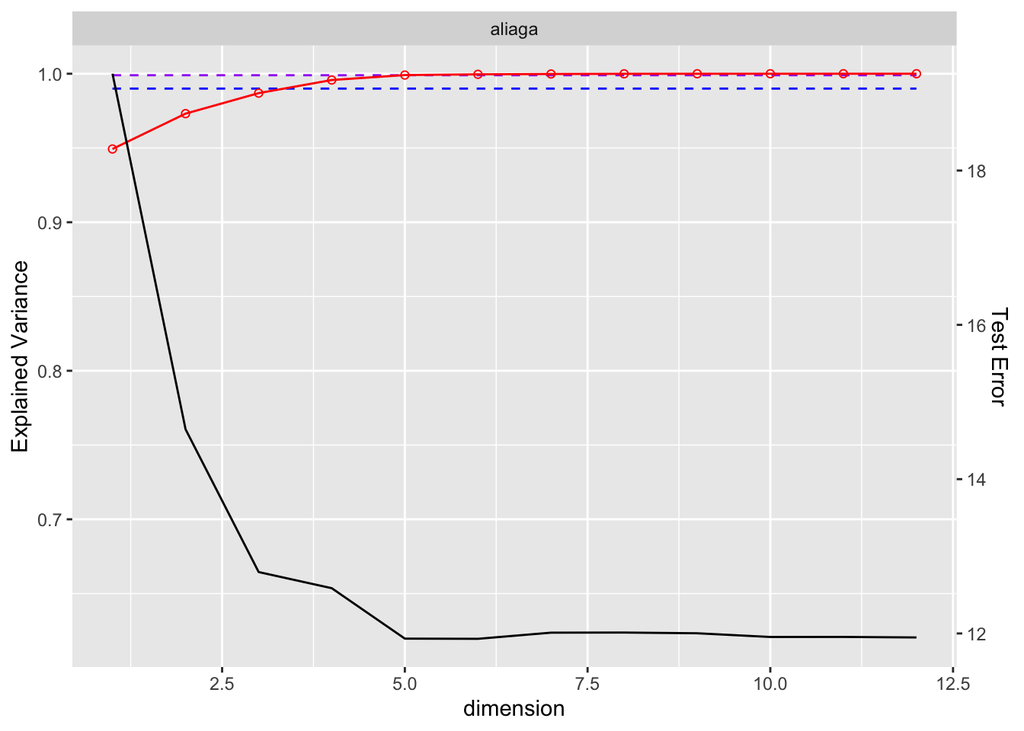

#### Bares

Bares Plot

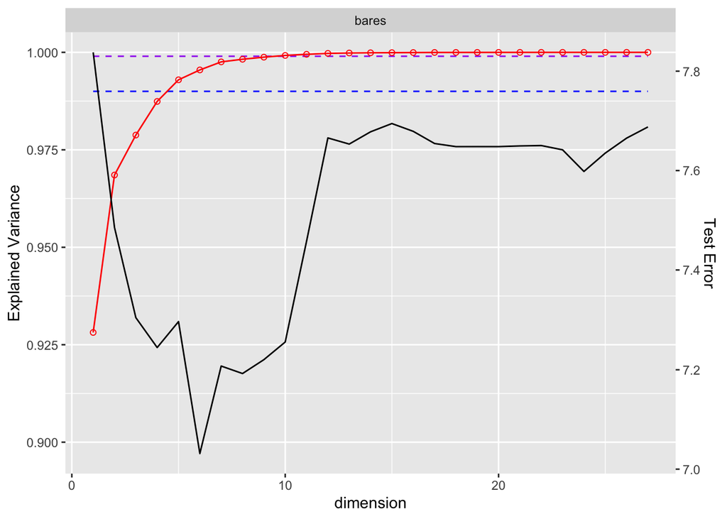

#### Dinar

Dinar Plot

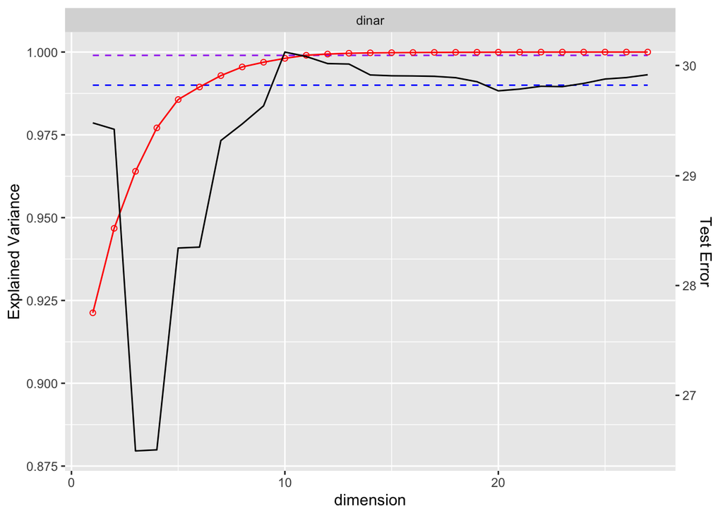

#### Geycek

Geycek Plot

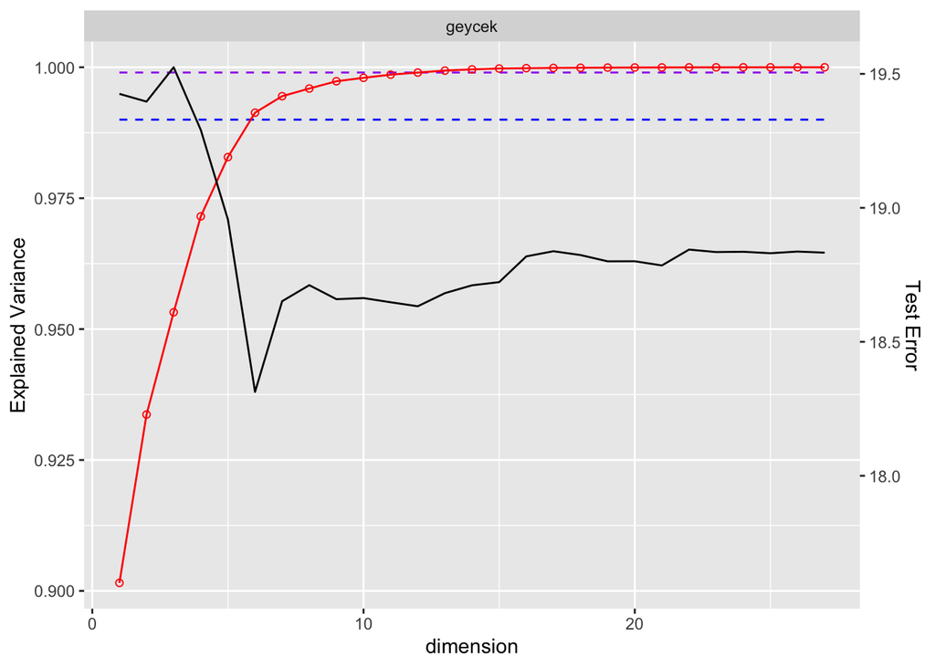

#### Soke

Soke Plot

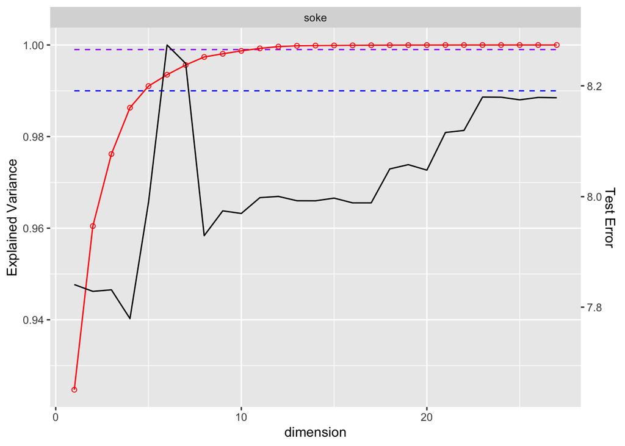

#### Soma

Soma Plot

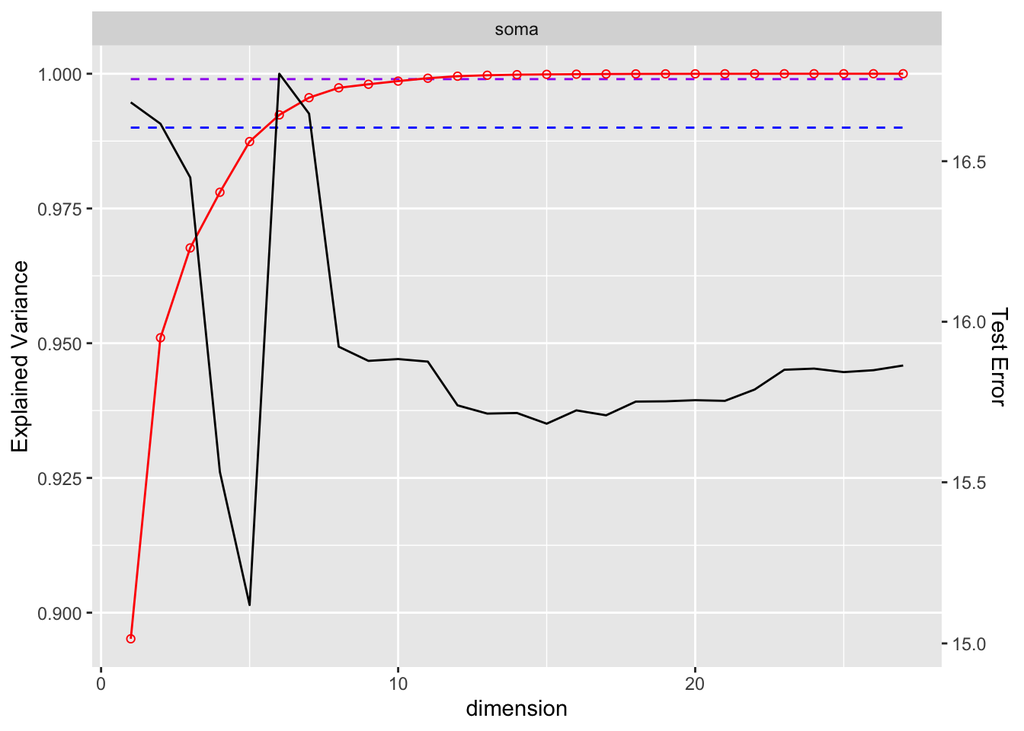

### Conclusion

- Kronecker’s explained variance and train/test errors look nice.
- Explained Variance is very high in the first PCs. (compare this to PCA and Kernel PCA)

## Kronecker PCA on POWER in Depth Analysis

### Figure 1

Here we see the change in train and test errors as we change the number of principal components in Kronecker PCA.

The numbers on the plot represent the number of PCs at the lowest test error.

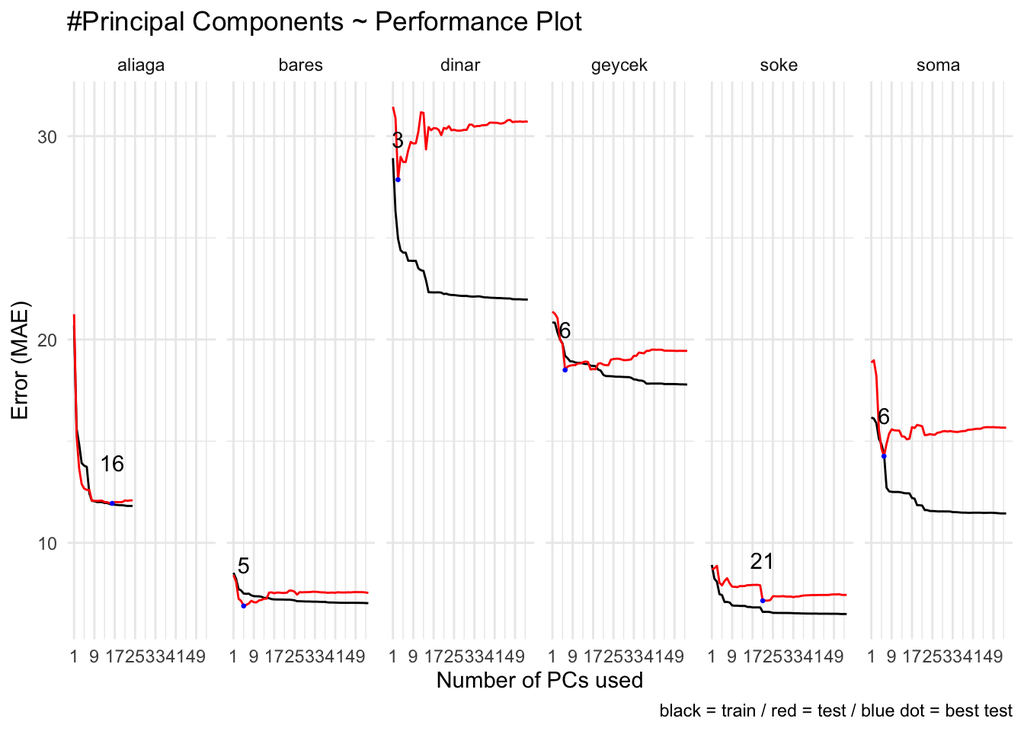

### Figure 2

Here we see the change in explained variance with number of principal components.

Blue and Purple lines represent 99%th and 99.9%th explained varience.

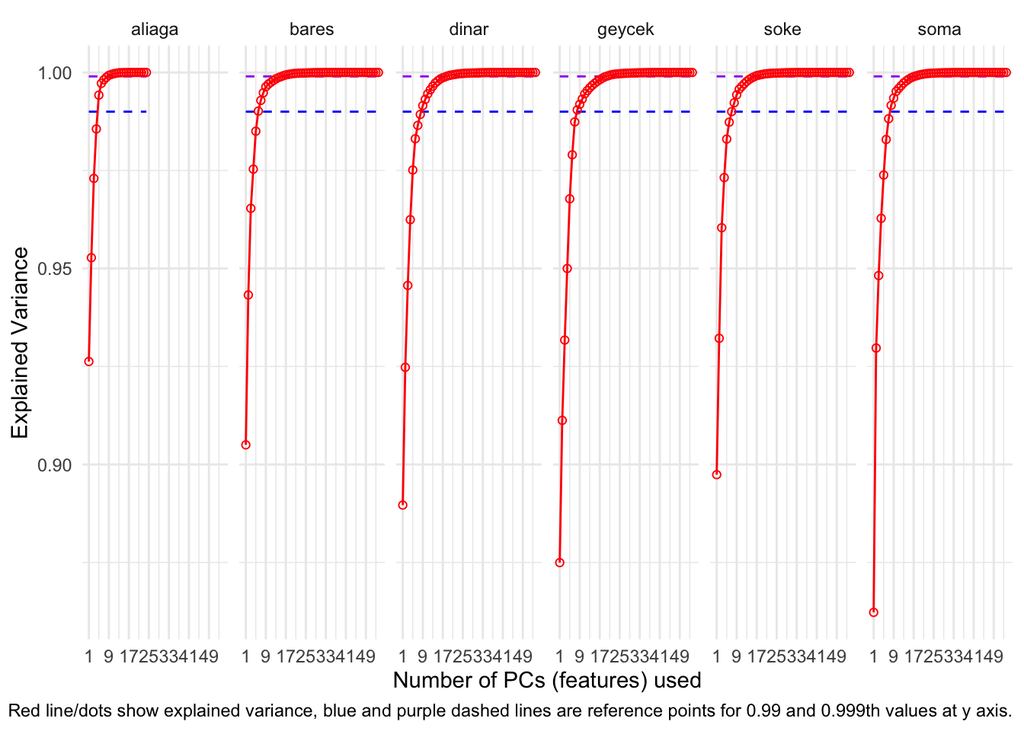

### Close Look

#### Aliaga

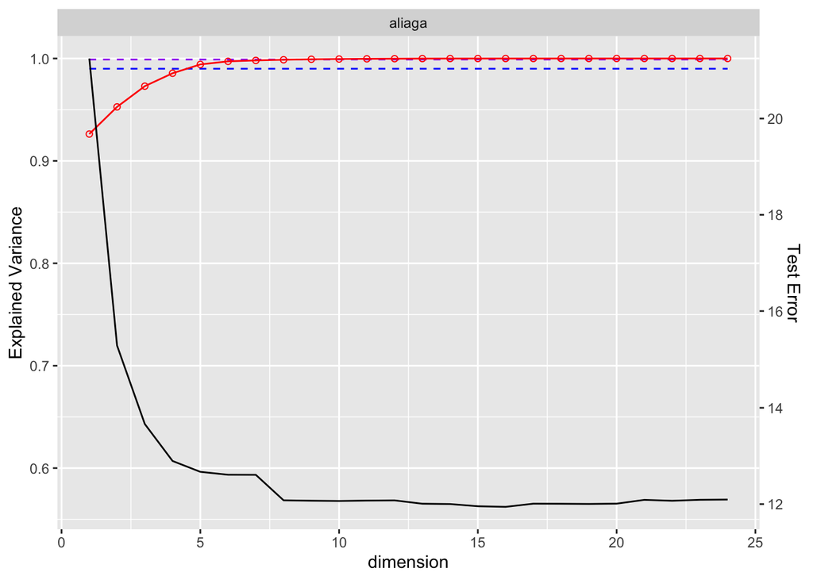

#### Bares

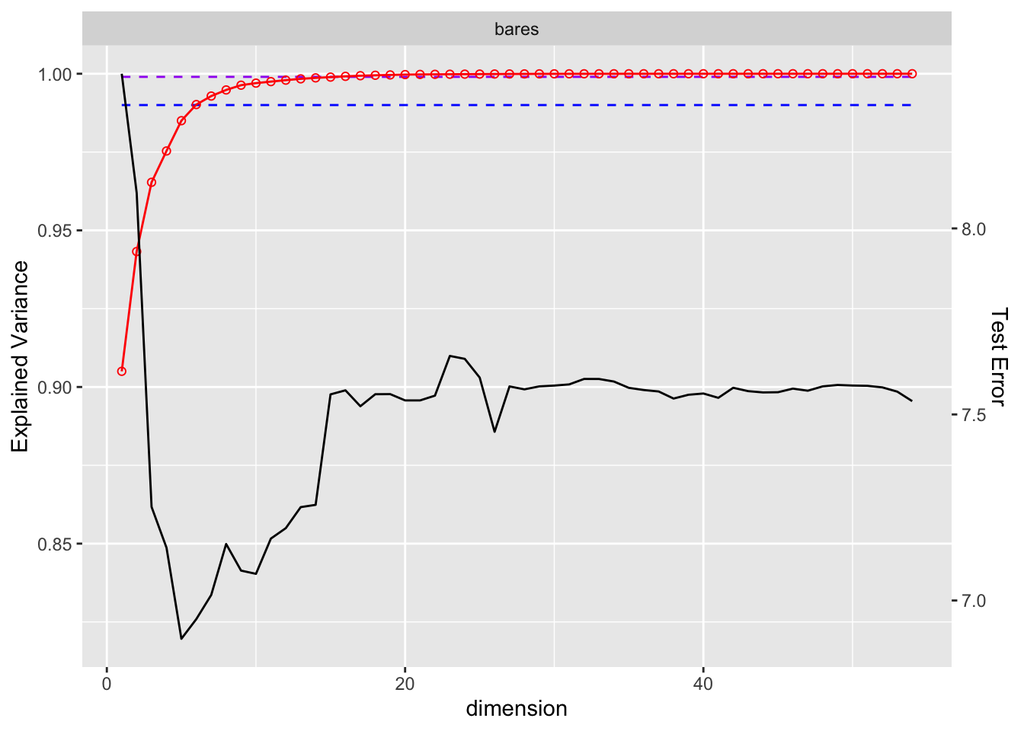

#### Dinar

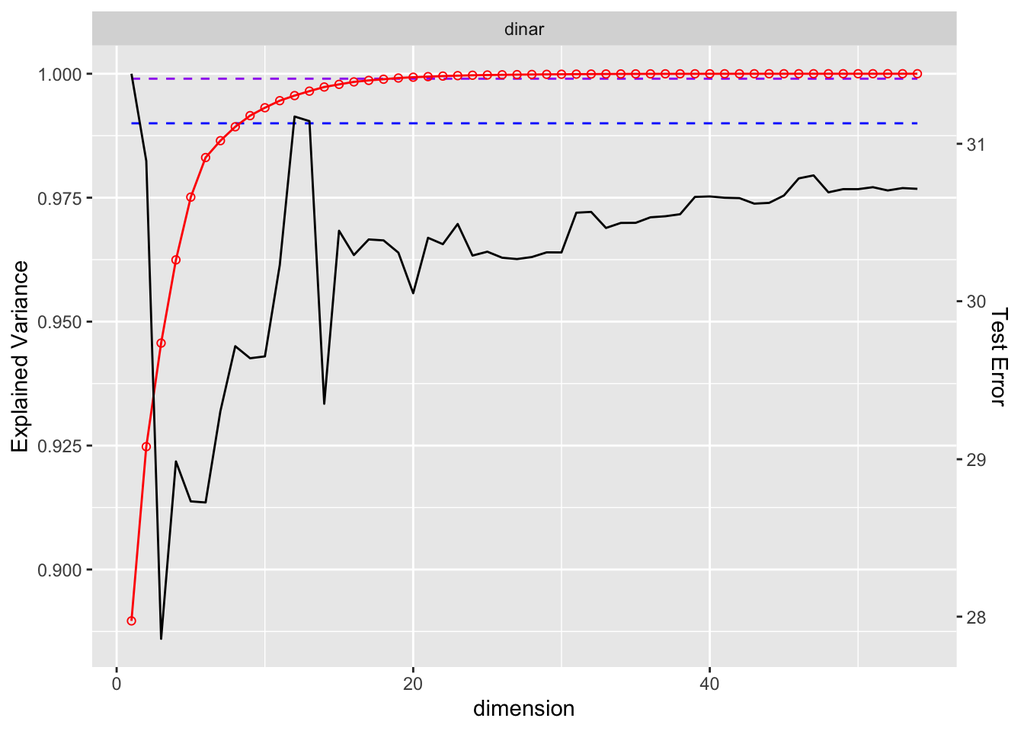

#### Geycek

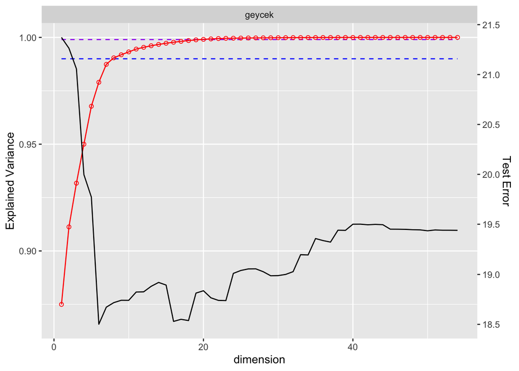

#### Soke

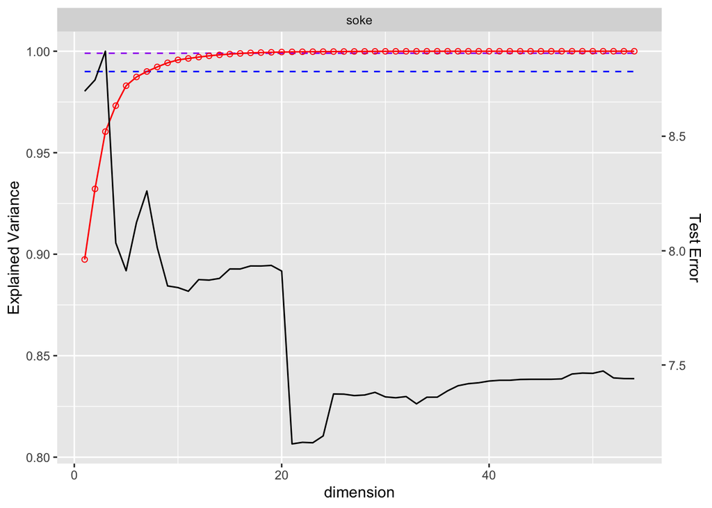

#### Soma

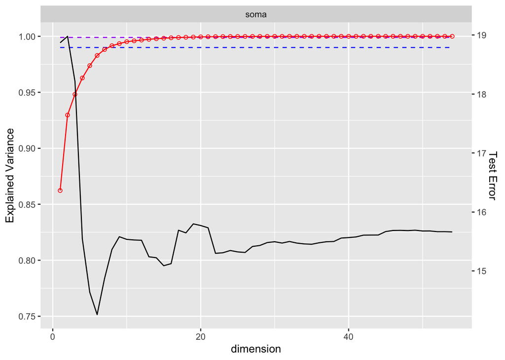